# Quality_Workout

Apurv Kaushal

26 August 2018

## Executive Summary

The report outlines the process of generating a robust prediction model for the Weight Lifting Exercise Datbase to predict the quality of the workout exercise based on an on body sensing approach. The random forest model applied PCA processed dataset gives the maximum validation set accuracy of about 96 % among the used classification techniques like Naive Bayes,Decision Tress & Support Vector Machine. The out of sample error rate is approxmately 4 % for the validation set separated from the original data.

## Experiment Background

Six young health participants were asked to perform one set of 10 repetitions of the Unilateral Dumbbell Biceps Curl in five different fashions: exactly according to the specification (Class A), throwing the elbows to the front (Class B), lifting the dumbbell only halfway (Class C), lowering the dumbbell only halfway (Class D) and throwing the hips to the front (Class E).

Class A corresponds to the specified execution of the exercise, while the other 4 classes correspond to common mistakes. Participants were supervised by an experienced weight lifter to make sure the execution complied to the manner they were supposed to simulate. The exercises were performed by six male participants aged between 20-28 years, with little weight lifting experience. We made sure that all participants could easily simulate the mistakes in a safe and controlled manner by using a relatively light dumbbell (1.25kg).

## Data Set Exploration

```r
library(caret)
set.seed(25)
dtset<-read.csv("C:\\Users\\Apurv kaushal\\Documents\\pml-training.csv")
str(dtset)
```

```
## 'data.frame':    19622 obs. of  160 variables:
##  $ X                       : int  1 2 3 4 5 6 7 8 9 10 ...
##  $ user_name               : Factor w/ 6 levels "adelmo","carlitos",..: 2 2 2 2 2 2 2 2 2 2 ...
##  $ raw_timestamp_part_1    : int  1323084231 1323084231 1323084231 1323084232 1323084232 1323084232 1323084232 1323084232 1323084232 1323084232 ...
##  $ raw_timestamp_part_2    : int  788290 808298 820366 120339 196328 304277 368296 440390 484323 484434 ...
##  $ cvtd_timestamp          : Factor w/ 20 levels "02/12/2011 13:32",..: 9 9 9 9 9 9 9 9 9 9 ...
##  $ new_window              : Factor w/ 2 levels "no","yes": 1 1 1 1 1 1 1 1 1 1 ...
##  $ num_window              : int  11 11 11 12 12 12 12 12 12 12 ...
##  $ roll_belt               : num  1.41 1.41 1.42 1.48 1.48 1.45 1.42 1.42 1.43 1.45 ...
##  $ pitch_belt              : num  8.07 8.07 8.07 8.05 8.07 8.06 8.09 8.13 8.16 8.17 ...
##  $ yaw_belt                : num  -94.4 -94.4 -94.4 -94.4 -94.4 -94.4 -94.4 -94.4 -94.4 -94.4 ...
##  $ total_accel_belt        : int  3 3 3 3 3 3 3 3 3 3 ...
##  $ kurtosis_roll_belt      : Factor w/ 397 levels "","-0.016850",..: 1 1 1 1 1 1 1 1 1 1 ...
##  $ kurtosis_picth_belt     : Factor w/ 317 levels "","-0.021887",..: 1 1 1 1 1 1 1 1 1 1 ...
##  $ kurtosis_yaw_belt       : Factor w/ 2 levels "","#DIV/0!": 1 1 1 1 1 1 1 1 1 1 ...
```

[output cut: 86 more lines]

Removing features with very high number of NA Values

```r
ntbl<-colSums(is.na(dtset))/nrow(dtset)
tempdf<-data.frame(colName=names(dtset),PropNA=matrix(unlist(ntbl)))
tempdf[,1]<-as.character(tempdf[,1])
indx<-which(tempdf$PropNA==0.0000000)
library(dplyr)
dtset1<-select(dtset,tempdf[indx,1])
```

Removing features with very high number of “” Values

```r
truthvec<-c()
k<-1
for (i in names(dtset1)){
  if (dtset1[1,i]==""){
    truthvec[k]<-"TRUE"
    k<-k+1
  }
  else{
    truthvec[k]<-"FALSE"
    k<-k+1
  }
}
dtset2<-dtset1[,truthvec=="FALSE"]
```

Removing correlated features

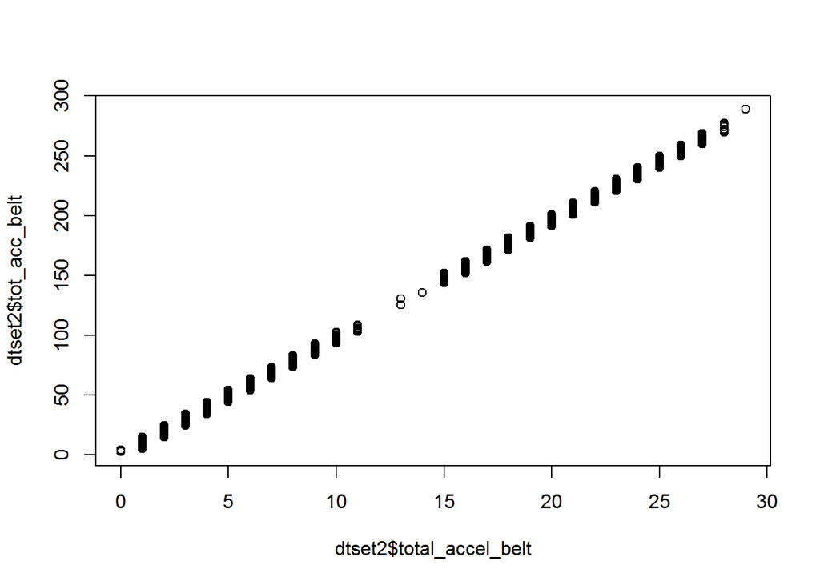

```r
dtset2$tot_acc_belt<-sqrt(dtset$accel_belt_x^2+dtset$accel_belt_y^2+dtset$accel_belt_z^2)
plot(dtset2$total_accel_belt,dtset2$tot_acc_belt)
```

```r
dtset2<-dtset2[,!grepl("^tot",names(dtset2))]
```

Removing features that should be logically uncorrelated to the prediction variable. The features being removed are X: it represents the serial no. of observations hence uncorrelated user_name: the user’s identity should not play a role in prediction as the metric for the correct workout is defined independently, for all human beings. raw_timestamp_1: it is the expression for a part of time of observation hence uncorrelated raw_timestamp_2: same reason as raw_timestamp_1 cvtd_timestamp: same reason as for raw_timestamp_1 new_window: it is a variable of the experimental conditions, indicating probably some sense of continuous time frame for observations between breaks. num_window: this feature keeps track of the number of breaks hence uncorrelated.

```r
dtset2<-dtset2[,8:ncol(dtset2)]
```

Further exploration of correlation between features

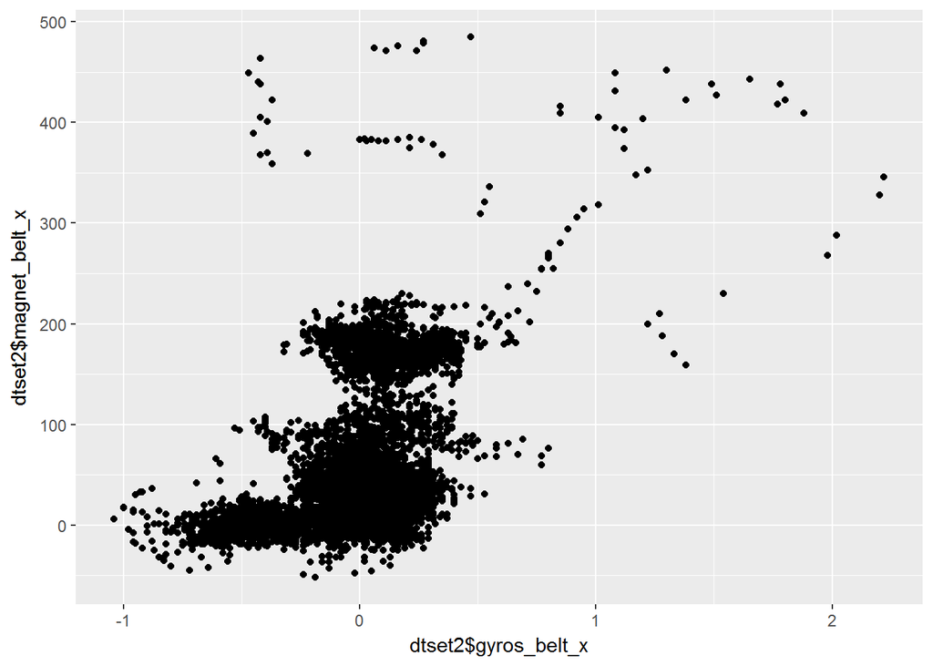

```r
qplot(dtset2$gyros_belt_x,dtset2$magnet_belt_x)
```

```r
tempdf<-dtset2[,1:12]
cor(tempdf)[which((cor(tempdf)>0.6 & cor(tempdf)<1 )| (cor(tempdf)< -0.6 & cor(tempdf)>-1))]
```

```
##  [1]  0.8152297  0.9248983 -0.9920085 -0.6997519 -0.9657334 -0.8841727
##  [7]  0.8152297 -0.6997519  0.7080277  0.6005466 -0.7764520  0.7365460
## [13] -0.9657334  0.7080277  0.8920913  0.9248983  0.6005466 -0.9333854
## [19] -0.9920085 -0.7764520 -0.9333854 -0.8841727  0.7365460  0.8920913
## [25]  0.7789335  0.7789335
```

```r
indx<-createDataPartition(y=dtset2$classe,p=3/4)[[1]]
trainset<-dtset2[indx,]
validset<-dtset2[-indx,]
pcmp<-prcomp(trainset[,1:48])
summary(pcmp)$importance
```

```
##                              PC1       PC2       PC3       PC4       PC5
## Standard deviation     598.18478 536.88297 472.93997 376.70538 355.16397
## Proportion of Variance   0.26225   0.21126   0.16393   0.10400   0.09245
## Cumulative Proportion    0.26225   0.47351   0.63744   0.74144   0.83389
##                              PC6       PC7       PC8       PC9      PC10
## Standard deviation     254.33813 201.21263 174.27192 157.87054 118.31165
## Proportion of Variance   0.04741   0.02967   0.02226   0.01827   0.01026
## Cumulative Proportion    0.88131   0.91098   0.93324   0.95150   0.96176
##                            PC11     PC12     PC13     PC14     PC15
## Standard deviation     96.88965 89.35217 76.14780 68.67215 62.63507
## Proportion of Variance  0.00688  0.00585  0.00425  0.00346  0.00288
## Cumulative Proportion   0.96864  0.97449  0.97874  0.98220  0.98508
##                            PC16     PC17     PC18     PC19     PC20
## Standard deviation     56.94251 53.12997 49.54257 48.70613 42.00161
## Proportion of Variance  0.00238  0.00207  0.00180  0.00174  0.00129
## Cumulative Proportion   0.98745  0.98952  0.99132  0.99306  0.99435
##                            PC21     PC22     PC23     PC24     PC25
## Standard deviation     37.79134 35.12804 32.79703 30.89160 25.31874
## Proportion of Variance  0.00105  0.00090  0.00079  0.00070  0.00047
## Cumulative Proportion   0.99540  0.99630  0.99709  0.99779  0.99826
##                            PC26     PC27     PC28     PC29     PC30
## Standard deviation     23.03591 21.39986 20.62604 17.18290 15.03770
## Proportion of Variance  0.00039  0.00034  0.00031  0.00022  0.00017
## Cumulative Proportion   0.99865  0.99898  0.99930  0.99951  0.99968
##                            PC31     PC32     PC33    PC34     PC35
## Standard deviation     13.86426 9.789215 7.655519 6.12352 4.650228
## Proportion of Variance  0.00014 0.000070 0.000040 0.00003 0.000020
## Cumulative Proportion   0.99982 0.999890 0.999930 0.99996 0.999980
##                            PC36     PC37     PC38     PC39      PC40
## Standard deviation     3.764539 3.452466 1.957917 1.531256 0.4679037
## Proportion of Variance 0.000010 0.000010 0.000000 0.000000 0.0000000
## Cumulative Proportion  0.999990 0.999990 1.000000 1.000000 1.0000000
##                             PC41      PC42      PC43      PC44      PC45
## Standard deviation     0.3921403 0.3628667 0.3142687 0.2415996 0.2065072
## Proportion of Variance 0.0000000 0.0000000 0.0000000 0.0000000 0.0000000
## Cumulative Proportion  1.0000000 1.0000000 1.0000000 1.0000000 1.0000000
##                             PC46      PC47       PC48
## Standard deviation     0.1873947 0.1050986 0.03650369
## Proportion of Variance 0.0000000 0.0000000 0.00000000
## Cumulative Proportion  1.0000000 1.0000000 1.00000000
```

The first 9 principal components explain 95 per cent of the variance in the data set. We will thus, use the first 9 components.

```r
prepc<-preProcess(trainset[,1:48],method="pca",pcaComp=9)
proctrain<-predict(prepc,trainset[,1:48])
proctrain$classe<-trainset$classe
```

Next, we will now fit classification models to the pre processed training data set. Naive Bayes

```r
mdl<-naiveBayes(classe~.,data=proctrain)
cf<-confusionMatrix(trainset$classe,predict(mdl,proctrain))$overall
```

Very low accuracy of 43 per cent on the training set itself. Hence the model is rejected. Decision Tree

```r
library(rpart)
mdl<-rpart(classe~.,data=proctrain,method="class")
cf<-confusionMatrix(trainset$classe,predict(mdl,proctrain,type="class"))$overall
```

Very low accuracy of 49 per cent on training set. Hence the model is rejected. SVM

```r
library(e1071)
mdl<-svm(classe~.,data=proctrain)
cf<-confusionMatrix(trainset$classe,predict(mdl,proctrain))$overall
proctest<-predict(prepc,validset[,1:48])
confusionMatrix(validset$classe,predict(mdl,proctest))$overall
```

```
##       Accuracy          Kappa  AccuracyLower  AccuracyUpper   AccuracyNull
##   8.073002e-01   7.553599e-01   7.959775e-01   8.182557e-01   3.156607e-01
## AccuracyPValue  McnemarPValue
##   0.000000e+00   3.800672e-37
```

Accuracy of 80 per cent on the training set. Accuracy of 80 per cent on the validation set too. Hence. the SVM model till now is the best model.

Random Forest

```r
mdl_rf<-train(classe~.,data=proctrain,method="rf")
confusionMatrix(validset$classe,predict(mdl_rf,proctest))$overall
```

```
##       Accuracy          Kappa  AccuracyLower  AccuracyUpper   AccuracyNull
##     0.95860522     0.94764564     0.95264844     0.96400783     0.28384992
## AccuracyPValue  McnemarPValue
##     0.00000000     0.02413492
```

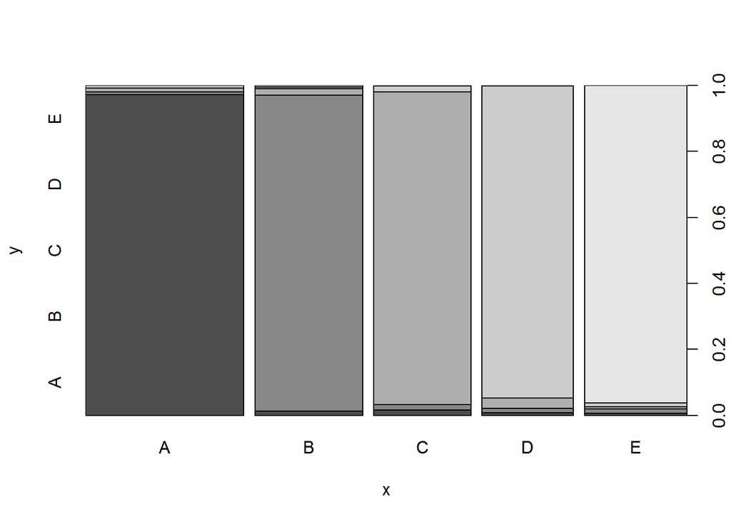

```r
plot(validset$classe,predict(mdl_rf,proctest))
```

With an Accuracy of about 96 per cent on the validation set, the random forest model is the best predictor. The out of sample error rate is 4 % on the validation set.